# Final Project EDA

Data Science 1 with R (STAT 301-1)

Author

Stephanie Xu

## Introduction

The Academy Awards, as known as the Oscars, is one of the most prestigious and significant awards in the entertainment industry. Among more than twenty Award of Merit categories, the nomination of Best Actors, Best Actress, Best Supporting Actors and Best Supporting Actress are highly anticipated by audience around the world.

### Purpose of the exploration

This project is focused on actors and actress nominated by Oscars for their performances in the last fifty years from 1972. Datasets used in the analysis are adapted from [IMDb](https://datasets.imdbws.com/) and [Oscar nominations and filmographies since 1972](https://www.kaggle.com/milanjanosov), which will be processed into two new datasets.

The analysis will be guided by the following prompts: - Explore number of Oscar nominations and wins for each actor/actress. - Explore the age when actors/actresses won Oscars Award or was nominated by Oscars. - Explore the reputation of nominated actors/actresses by analyzing ratings of the films they are playing roles in. - Cross-datasets analysis is also used to explore the relationship between variables in the two datasets.

## Load Packages

```r
library(tidyverse)
library(janitor)
```

## Process Datasets

### Description of the source of raw datasets

The major and the most important datasets in this project are provided by [IMDb](https://datasets.imdbws.com/) (IMDb Data Files Available for Download). There are 7 datasets available and I will only choose 4 of them and join them together.

To aid my analysis, I also incorporate the dataset [nomination_stats](https://www.kaggle.com/datasets/milanjanosov/oscar-nominations-and-filmographies-since-1972) contributed by milanjanosov on Kaggle. The convenience of this dataset is that it use the same unique identifier for films (`tconst`) and actresses/actors (`nconst`) as IMDb.

### Import raw datasets

```r
title<- read_tsv("data/raw/title.basics.tsv",
                 na = c("\\N", ""))%>%
  clean_names()

ratings <- read_tsv("data/raw/title.ratings.tsv",
                    na = "\\N") %>%
  clean_names()

principals <-read_tsv("data/raw/title.principals.tsv",
                      na = "\\N") %>%
  clean_names()

name_doc <- read_tsv("data/raw/name.basics.tsv",
                     na = "\\N") %>%
  clean_names()

nomination_stats <- read_csv("data/raw/nomination_stats.csv") %>%
  clean_names()
```

After importing the raw datasets, the warnings generated indicates that there are parsing issues in `title` and `principals` datasets. So I use `problems()` to find out source of the issues.

```r
# Find out rows and columns where parsing issues occur
problems(title)
```

```
# A tibble: 30 × 5
       row   col expected  actual      file
     <int> <int> <chr>     <chr>       <chr>
 1 1097682     8 9 columns 8 columns   /Users/xujinghan/Desktop/data science/st…
 2 1097682     8 a double  Reality-TV  /Users/xujinghan/Desktop/data science/st…
 3 1508850     8 9 columns 8 columns   /Users/xujinghan/Desktop/data science/st…
 4 1508850     8 a double  Talk-Show   /Users/xujinghan/Desktop/data science/st…
 5 1898135     8 9 columns 8 columns   /Users/xujinghan/Desktop/data science/st…
 6 1898135     8 a double  Documentary /Users/xujinghan/Desktop/data science/st…
 7 2009209     8 9 columns 8 columns   /Users/xujinghan/Desktop/data science/st…
 8 2009209     8 a double  Talk-Show   /Users/xujinghan/Desktop/data science/st…
 9 2163888     8 9 columns 8 columns   /Users/xujinghan/Desktop/data science/st…
10 2163888     8 a double  Game-Show   /Users/xujinghan/Desktop/data science/st…
# … with 20 more rows
```

```r
problems(principals)
```

```
# A tibble: 1 × 5
       row   col expected  actual    file
     <int> <int> <chr>     <chr>     <chr>
1 17026518     5 6 columns 5 columns /Users/xujinghan/Desktop/data science/stat…
```

I looked back into the raw data file using a text editor according to rows and columns where problems occurs. It turns out that those rows will eventually be filtered, as those information has nothing to do with my focus of analysis on film. So I didn’t spend time on fixing those problems.

### Tidy and join datasets

I performed several filtering and joining steps to reduce the size of the datasets so it only contains information that will be used in my analysis.

```r
#Combining IMDb datasets
movie_full<- title %>%
  #First filter the dataset and maintain only movie related rows
  filter(title_type == "movie") %>%
  #Then join with other datasets by unique identifiers
  inner_join(principals, by = "tconst") %>%
  inner_join(name_doc, by = "nconst") %>%
  left_join(ratings, by = "tconst")
```

After combining the IMDb datasets and store it as `movie_full`, I merged it with `nomination_stats` and obtained two final datasets: - `nominees_and_winners`: this dataset includes basic information for each year’s nomination of Oscars Award. - `nominees_rating`: this dataset is obtained by joining the IMDb datasets and the nomination datasets, which includes all the ratings for films that each Oscars nominees once played a role in.

```r
nominees_and_winners<- movie_full %>%
  arrange(nconst) %>%
  distinct(nconst, birth_year) %>%
  right_join(nomination_stats, c("nconst" = "name_id")) %>%
  arrange(year) %>%
  select(year, category, name, nconst, birth_year, outcome)

nominees_rating <- nominees_and_winners %>%
  distinct(nconst, name) %>%
  inner_join(movie_full, "nconst") %>%
  select(name, nconst, primary_title, tconst, average_rating, start_year)
```

### Discussion of NA values

To check for `NA` values, I also defined a helper function `get_NA()` that will return a tibble with rows where any `NA` occurs.

```r
# Defining function
get_NA <- function (df){
  colnms <- colnames (df)
  df %>%
    filter_at(vars(all_of(colnms)), any_vars(is.na(.)))
}
```

```r
get_NA(nominees_and_winners)
```

```
# A tibble: 1 × 6
   year category                          name            nconst birth…¹ outcome
  <dbl> <chr>                             <chr>           <chr>    <dbl> <chr>
1  1981 Best Actress in a Supporting Role Eva Le Gallien… nm049…      NA nominee
# … with abbreviated variable name ¹birth_year
```

First I checked the dataset `nominees_and_winners` it turns out that there is only one row with a missing value of this actress’s birth year. As my exploration will include age of the artist, the birth year is very crucial. So I searched online and fill the her birth year into the blank. The birth year is adapted from Wikipedia ([“Eva Le Gallienne”](https://en.wikipedia.org/wiki/Eva_Le_Gallienne)).

```r
# This step is to find the row number that this `NA` occurs
which(str_detect(nominees_and_winners$nconst, "nm0499170"))
```

```
[1] 240
```

```r
# This step replace NA with her actual birth year
nominees_and_winners[240, "birth_year"] <- 1899
```

I then applied the `get_NA()` function to `nominees_rating` dataset.

```r
nominees_rating %>%
  get_NA() %>%
  summary()
```

```
     name              nconst          primary_title         tconst
 Length:2279        Length:2279        Length:2279        Length:2279
 Class :character   Class :character   Class :character   Class :character
 Mode  :character   Mode  :character   Mode  :character   Mode  :character




 average_rating   start_year
 Min.   :5.1    Min.   :1932
 1st Qu.:5.1    1st Qu.:2006
 Median :5.1    Median :2019
 Mean   :5.1    Mean   :2011
 3rd Qu.:5.1    3rd Qu.:2023
 Max.   :5.1    Max.   :2028
 NA's   :2278   NA's   :1482
```

For missing ratings, the IMDb officialy responds that they only display the rating of films with at least five votes ([IMDb | Help](https://help.imdb.com/article/imdb/track-movies-tv/ratings-faq/G67Y87TFYYP6TWAV?recentlyAuthenticated=true#)). In other words, the missing ratings are a result of not enough audience. Therefore, I will drop these rows with missing ratings when doing analysis, as films that have limited views won’t impact a lot on the reputation (audience’s perception) of an artists.

Finally, the two processed datasets are saved as `.rds` format in my file.

```r
write_rds(nominees_rating, "data/processed/nominees_rating.rds")
write_rds(nominees_and_winners, "data/processed/nominees_and_winners.rds")
```

## Exploration

### Distribution of Oscars Awards

First, I seperate `nominees_and_winners` based on the two outcome: `winner` and `nominee`.

```r
winners <- nominees_and_winners %>%
  filter(outcome == "winner")
nominees <- nominees_and_winners %>%
  filter(outcome == "nominee")
```

Note that there is an overlap between the dataset `winners` and `nominees`: each winner is also recorded as nominee.

```r
#Total number of nominees: 556
nominees_and_winners %>%
  distinct(name) %>%
  nrow()
```

```
[1] 556
```

```r
#Total number of winners: 172
winners %>%
  distinct(name) %>%
  nrow()
```

```
[1] 172
```

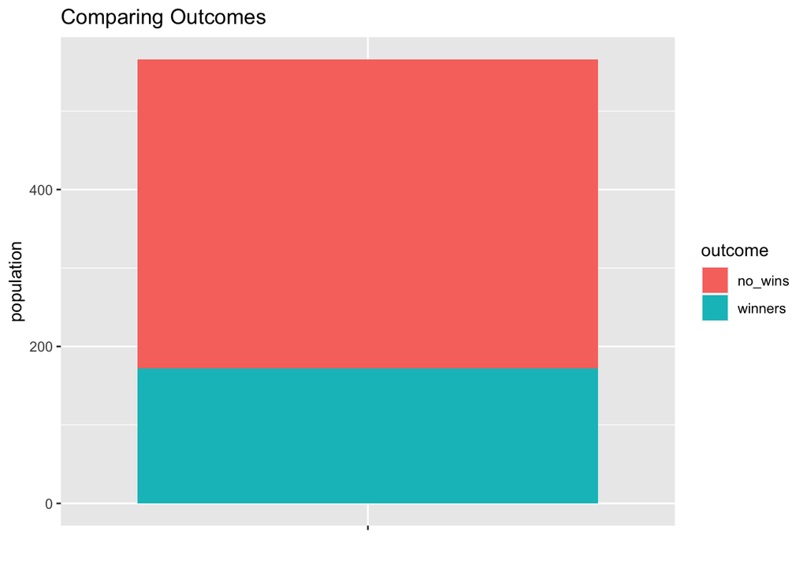

```r
# Nomination summary
nom_summary <- tibble(
  outcome = c("winners", "no_wins"),
  population = c(172, 566 - 172))

nom_summary %>%
  ggplot(aes(x = "", y = population, fill = outcome))+
  geom_bar(stat = "identity")+
  labs(x = "",
       title = "Comparing Outcomes")
```

This graph visualize the number of artists who wins one or more Oscars Awards and the number of artists who has never won an award among all artists who has been nominated. It can be observed from the graph that the award winners account for roughly only 1/3 of total nominated population. However, each winner is selected among five nominees, so ideally the number of winners will be 1/5 of the total artist population. The difference between the observed and ideal proportions indicate that there must be artists who have multiple wins or nominations.

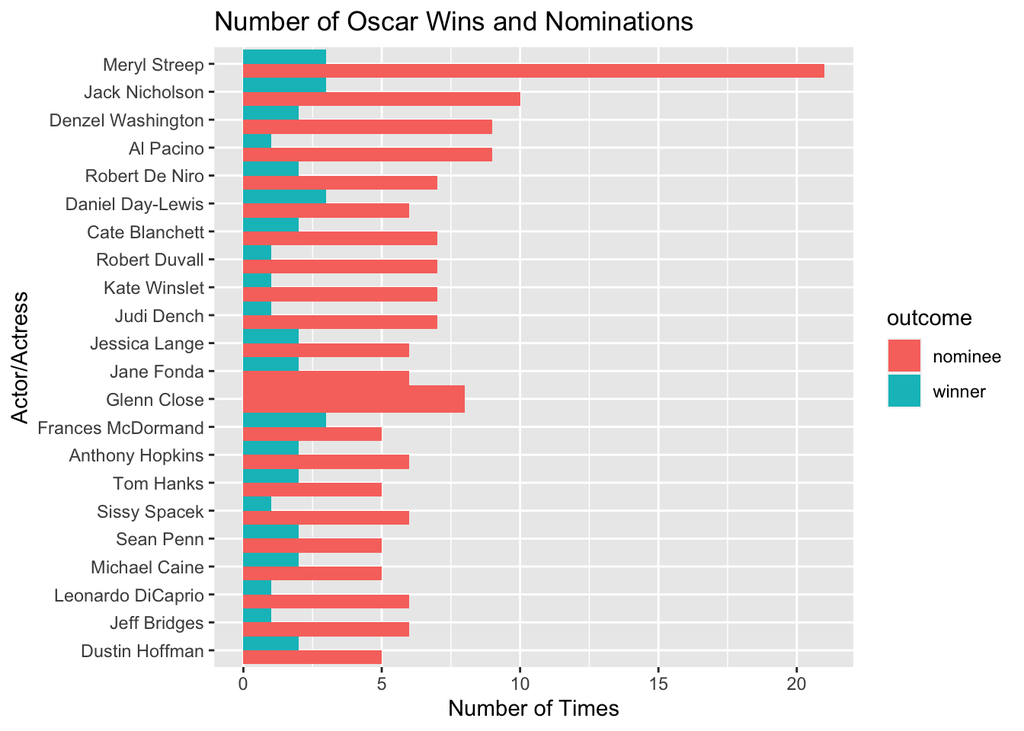

```r
# Explore the number of times for each artist who wins or is nominated
nominees_and_winners %>%
  group_by(name) %>%
  summarize(
    name = name,
    n = n(),
    outcome = outcome
  ) %>%
  arrange(desc(n)) %>%
  filter(n > 6) %>%
  ggplot(aes(y=fct_reorder(name,n)))+
  geom_bar(aes(fill = outcome), width = 1, position = "dodge")+
  labs(title="Number of Oscar Wins and Nominations",
       y = "Actor/Actress",
       x = "Number of Times")
```

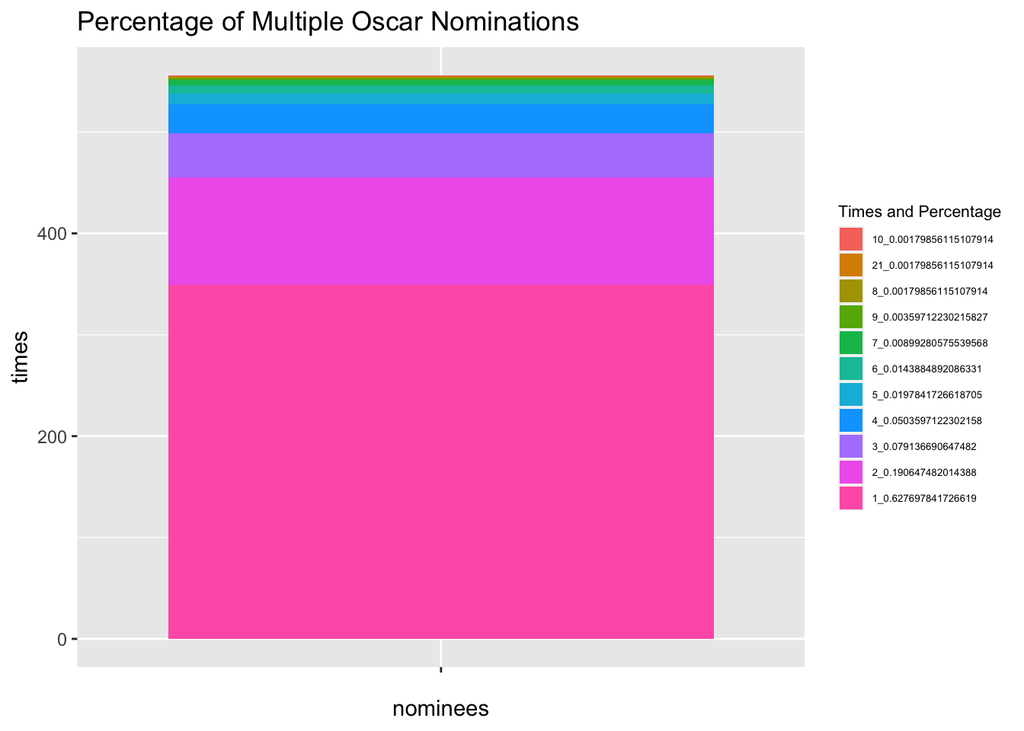

```r
# times of nomination in percentage
nomination_times <- nominees %>%
  count(name, nconst)%>%
  arrange(desc(n))

nomination_times %>%
  group_by(n) %>%
  summarize(
    times = n()
  ) %>%
  mutate(
    prop = times/sum(times)
  )%>%
  unite(groups, n, prop, sep = "_") %>%
  ggplot(aes(x = "", y=times, fill = fct_reorder(groups, times)))+
  geom_bar(stat="identity")+
  labs(title = "Percentage of Multiple Oscar Nominations",
       fill = "Times and Percentage",
       x = "nominees")+
  theme(legend.title = element_text(size = 8),
        legend.text = element_text(size = 5),
        legend.key.size = unit(0.45, "cm"))
```

This bar chart shows the percentage of the population of artists based on nominations they received. Artists who receive only one nomination account for about 62.78% of the total population. The percentage decreases sharply as the times being nominated increases. Having more than 6 times nominations is a very small occasion, as the population of receiving nominations above this is (from 7 to 21 times) less than 1% each.

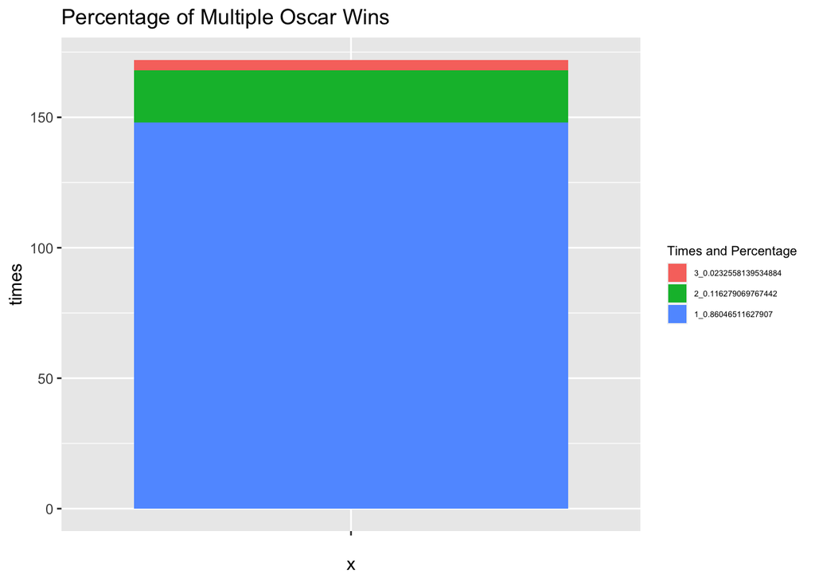

```r
# Award winners by name and times
win_times <- winners %>%
  count(name, nconst) %>%
  arrange(desc(n))

# Award winners in percentage
win_times %>%
  group_by(n) %>%
  summarize(
    times = n()
  ) %>%
  mutate(
    prop = times/sum(times)
  ) %>%
  unite(groups, n, prop, sep = "_") %>%
  ggplot(aes(x = "", y=times, fill = fct_reorder(groups,times)))+
  geom_bar(stat="identity")+
  labs(title = "Percentage of Multiple Oscar Wins",
       fill = "Times and Percentage")+
  theme(legend.title = element_text(size = 8),
        legend.text = element_text(size = 5),
        legend.key.size = unit(0.45, "cm"))
```

A similar trend can be observed when looking at Oscars winners who have different times of wins. The population with one Oscars win is the largest which takes up 86.05% of the total population, which is even larger than the population with one Oscars nomination. As the number of wins increases, the percentage of population decreases drastically. The maximum amount of Oscars wins of an artist is three, much smaller than the maximum amount of Oscars nominations.

### Distribution of the nominee’s age

In this section, I will explore the distribution of the age of Oscars nominees (including winners), particularly the age when they first won or were first nominated.

To analyze the data efficiently, I defined three helper functions combining with iteration:

```r
# To calculate the age when the artist is nominated or wins
calc_age <- function (df){
  df %>%
    mutate(age = .$year - .$birth_year)
}

# # To find the oldest nominees/winners using iteration
# max_age <- function(df){
#   output <- 0
#   for (i in seq_along(df$age)){
#      while (df$age[[i]] > output){
#        output <- df$age[[i]]
#      }
#   }
#   output
# }

#To find the youngest nominees/winners using iteration
min_age <- function(df){
  output <- df$age[[1]]
  for (i in seq_along(df$age)){
    while (output > df$age[[i]]){
      output <- df$age[[i]]
    }
  }
  output
}
```

Then, I use the `min_age()` function to find the age when the artist first wins or is nominated by Oscars Awards. The results are saved in two datasets:

```r
# The age of artists when they are first nominated
age_first_nominated <-
  nominees %>%
  calc_age() %>%
  split(.$name) %>%
  map_dbl(min_age) %>%
  enframe() %>%
  rename("age" = "value")

# The age of artists when they first win the award
age_first_win <-
  winners %>%
  calc_age() %>%
  split(.$name) %>%
  map_dbl(min_age) %>%
  enframe() %>%
  rename("age" = "value")
```

The distribution of the age of artists when they are first nominated is visualized in the following histogram:

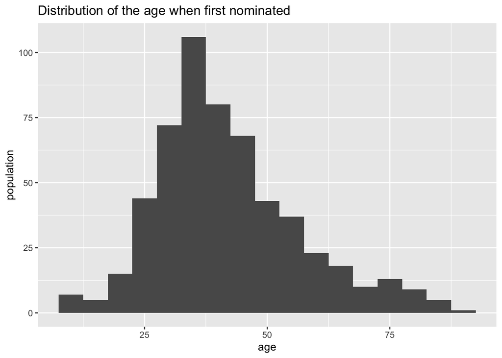

```r
age_first_nominated %>%
  ggplot(aes(x = age))+
  geom_histogram(binwidth = 5)+
  labs(title = "Distribution of the age when first nominated",
       y = "population")
```

```r
summary(age_first_nominated)
```

```
     name                age
 Length:556         Min.   : 9.00
 Class :character   1st Qu.:32.00
 Mode  :character   Median :39.00
                    Mean   :41.97
                    3rd Qu.:50.00
                    Max.   :88.00
```

The distribution of the age here is right skewed, with a median of 39 years old and mean of 41.97 years old. The minimum age being nominated by Oscars Awards is 9 years old, and the maximum age being nominated by Oscars Awards is 88 years old.

```r
age_first_nominated %>%
  filter(age == 9)
```

```
# A tibble: 1 × 2
  name           age
  <chr>        <dbl>
1 Justin Henry     9
```

```r
age_first_nominated %>%
  filter(age == 88)
```

```
# A tibble: 1 × 2
  name            age
  <chr>         <dbl>
1 Gloria Stuart    88
```

After looking into the dataset, I found that the youngest Oscars nominee is Justin Henry, and the Oldest Oscars nominee is Gloria Stuart.

The distribution of the age of artists when they first win the Oscars Award is visualized in this chart:

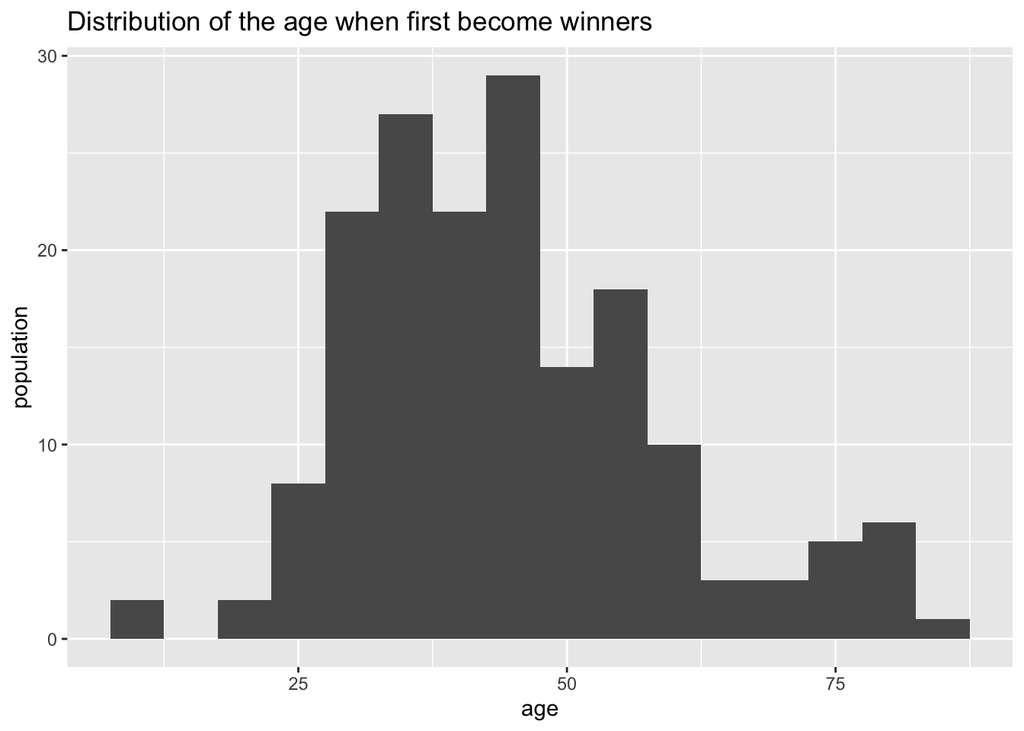

```r
age_first_win %>%
  ggplot(aes(x = age))+
  geom_histogram(binwidth = 5)+
  labs(title = "Distribution of the age when first become winners",
       y = "population")
```

```r
summary(age_first_win)
```

```
     name                age
 Length:172         Min.   :11.00
 Class :character   1st Qu.:34.00
 Mode  :character   Median :43.00
                    Mean   :44.75
                    3rd Qu.:53.00
                    Max.   :83.00
```

The distribution of age here is slightly right skewed, with a median of 43 years old and a mean of 44.75 years old. Compared to the `age_first_nomination` dataset, the `age_first_win` dataset has an increase in population as the age increase from the 67.5-72.5 category to the 77.5-82.5 category.

```r
age_first_win %>%
  filter(age == 11)
```

```
# A tibble: 1 × 2
  name           age
  <chr>        <dbl>
1 Tatum O'Neal    11
```

```r
age_first_win %>%
  filter(age == 83)
```

```
# A tibble: 1 × 2
  name                  age
  <chr>               <dbl>
1 Christopher Plummer    83
```

Tatum O’Neal is the youngest artist who wins Oscars Awards at the age of 11, and Christopher Plummer is the oldest artist who wins Oscars Award at the age of 83.

To have a more direct comparison between the two datasets, I also combine the two graphs together and displaying the datasets in boxplot:

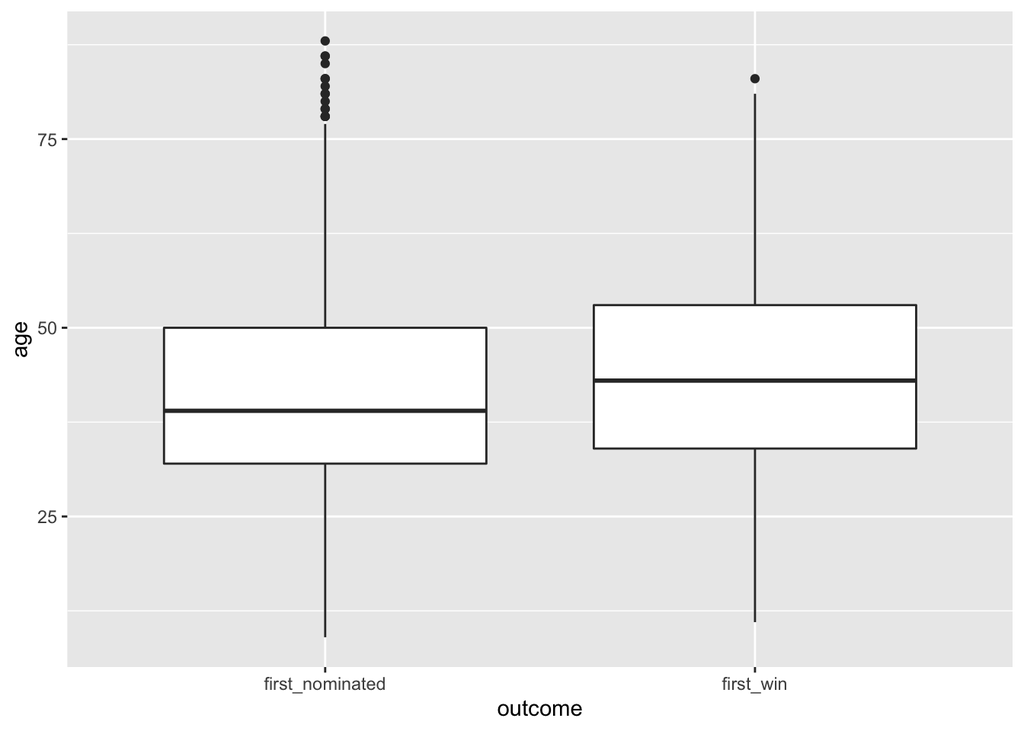

```r
age_compare <-
  age_first_nominated %>%
  left_join(age_first_win, by = "name") %>%
  rename("first_nominated" = "age.x",
         "first_win" = "age.y") %>%
  pivot_longer(c(first_nominated, first_win),
               names_to = "outcome",
               values_to = "age")
age_compare %>%
  ggplot(aes(x= outcome, y = age))+
  geom_boxplot(na.rm = TRUE)
```

In general, both nominations and wins occur more frequently in the age group 30-50. But artists win their first Oscars Awards at an older age compare to have their first Oscars nominations. This may because older artists usually have more experience and thus are more skillful in performance. Besides, the `age_first_nomination` dataset has more outliers/extreme large values at tails, indicating that the voting members also nominate artists at an older age.

### Reputation of Oscars nominees and winners

#### Discussion of `NA` values

Here I use the average rating of the films artists play a role in to represent their reputation among audiences.

#### Distribution of artists’ reputation

```r
# Group the dataset by "nconst" and calculate the average ratings for each artist
reputation <- nominees_rating %>%
  group_by(nconst) %>%
  summarize(
    name = name,
    ratings = mean(average_rating, na.rm = TRUE)
  ) %>%
  distinct(nconst, name, ratings) %>%
  arrange(desc(ratings))
```

After calculating the rating for each nominee and saving the data as new a dataset `reputation`, I visualize the distribution of Oscars nominees’ ratings in histogram:

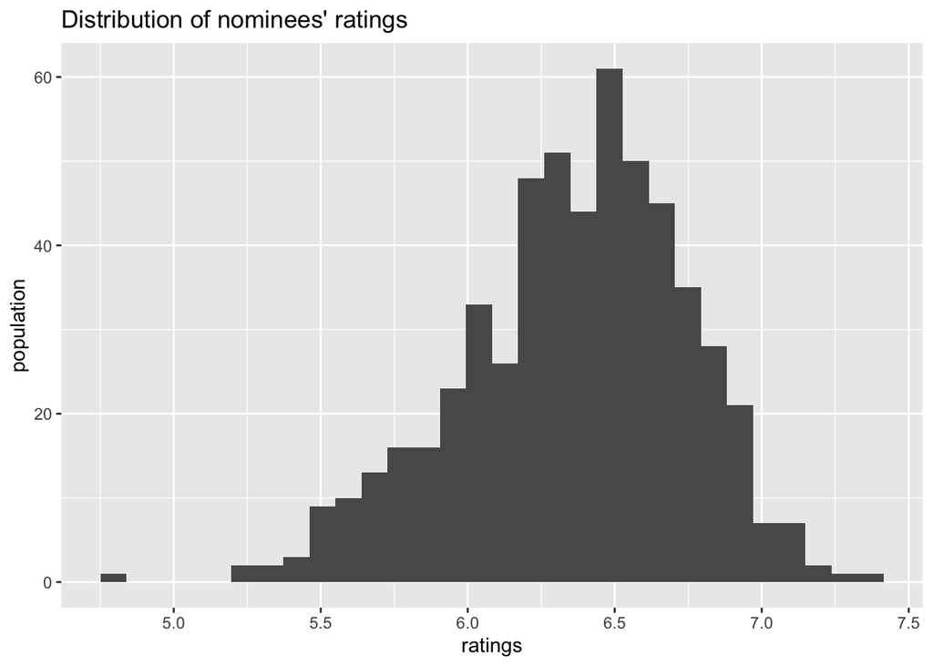

```r
reputation %>%
  ggplot(aes(x = ratings))+
  geom_histogram()+
  labs(title = "Distribution of nominees' ratings",
       y = "population")
```

```r
summary(reputation$ratings)
```

```
   Min. 1st Qu.  Median    Mean 3rd Qu.    Max.
  4.825   6.122   6.396   6.357   6.629   7.400
```

The distribution of Oscars nominees’ ratings is slightly left skewed, which means that in general audiences’ impression of them is above average (if to say the average corresponds to a rating of 5.0). The mean rating is 6.357 and the median rating is 6.396, with a maximum rating of 7.400 and minimum rating of 4.825.

A closer look at who are the nominees with best or worst reputations can be found in the following bar charts:

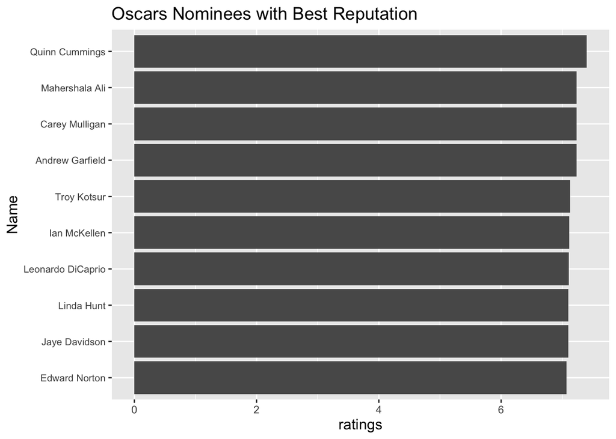

```r
# Nominees with top 10 ratings
reputation %>%
  head(n = 10) %>%
  ggplot(aes(y = fct_reorder(name, ratings), x = ratings))+
  geom_col()+
  labs(title = "Oscars Nominees with Best Reputation",
       y = "Name")+
  theme(title = element_text(size = 12),
        axis.text.y = element_text(size = 8))
```

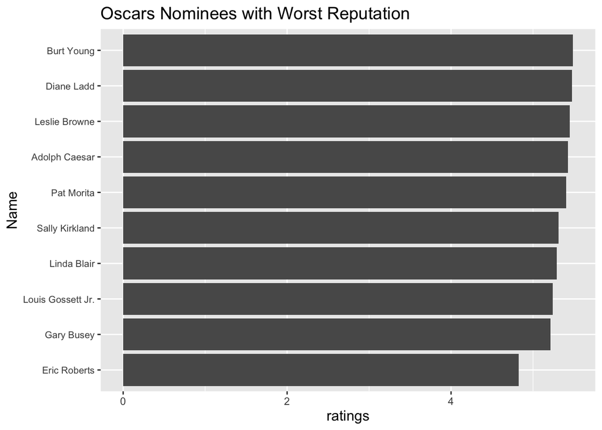

```r
# Nominees with least 10 ratings
reputation %>%
  tail(n = 10) %>%
  ggplot(aes(y = fct_reorder(name, ratings), x = ratings))+
  geom_col()+
  labs(title = "Oscars Nominees with Worst Reputation",
       y = "Name")+
  theme(title = element_text(size = 12),
        axis.text.y = element_text(size = 8))
```

However, even for nominees with least ratings, their average ratings are still above 5.0 except Eric Roberts.

### The Oscars Awards and the rating

In this section, I will implement cross-dataset analysis to explore factors that influence the rating.

#### Relationship between the amount of wins or nominations and ratings artists receive

It is possible that there will be an relationship between the amount of wins or nominations received by an artists and the ratings they receive.

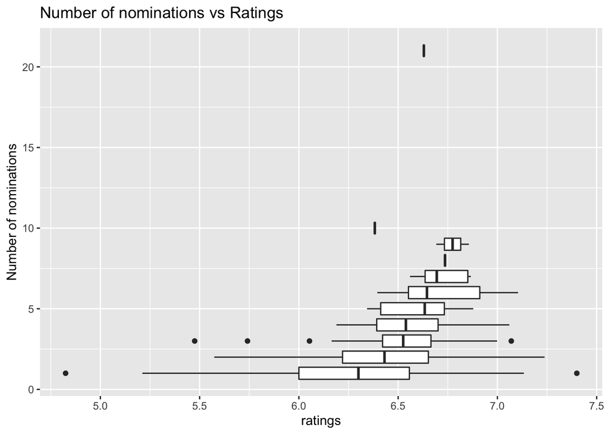

```r
# Correlation between the number of nominations and ratings
reputation %>%
  inner_join(select(nomination_times, n, nconst), by = "nconst") %>%
  ggplot(aes(x = ratings, y = n, group = n))+
  geom_boxplot()+
  labs(title = "Number of nominations vs Ratings",
    y = "Number of nominations")
```

By comparing the number of nominations and the distribution of ratings corresponding to each category of nomination amount, we can observe a trend that as the number of nominations increases, ratings in general will also increases. But there are outliers like Meryl Streep who has 21 nominations but has a rating of 6.63 and Jack Nicholson with 10 nominations but has rating of 6.38.

[figure not shown]

```r
# Correlation between number of wins and reputation

reputation %>%
  inner_join(select(win_times, nconst, n), by = "nconst") %>%
  ggplot(aes(x = ratings, y = n, group = n))+
  geom_boxplot()+
  labs(title = "Number of nominations vs Ratings",
    y = "Number of nominations")
```

The relationship between the number of wins and ratings of artists has similar characteristics to the relationship between the number of nominations and ratings. As the number of wins increases, the ratings will also increases. The difference is that the medians of ratings have larger range in the in nominated artists than in winners, in terms of both lowest median and the highest median. It might because there’s larger amount of nominees, which leads to larger variations in data. But another explanation can be that the winning an Oscars Award doesn’t define the quality of performance and audiences’ perception of the artists. It is possible that a high-skilled actors/actress has never won an Oscars Award. For example, Quinn Cummings has the highest rating, best has never won Oscars Awards.

The positive correlation shown in the two graphs here might indicate that Oscars’s voting members’ perception of artists is in accordance with the audience’s perception of artists. It is possible that the result of Oscars Awards will influence audiences expectations and perceptions of the film, or the public’s perception of a film will influence voting member’s decision. However, whether there is a causality between the two is not clear.

#### Relationship between the age and the ratings

People usually link the age when a person reveal a certain level of extraordinary characteristics to the talent that person has in the specific field. Usually, the younger the age, the more talented this person is. In the context of entertainment industry, the specialty of an actor/actress is signaled by winning or nominated by an prestigious award like the Oscars Awards.

To investigate whether the linkage is reasonable or true to the entertainment industry, I will explore the relationship between the age when artists first win or are nominated by the Oscars and the their ratings. Here winning an award or being nominated represent their extraordinary specialties and the ratings represent their talents perceived by the audience.

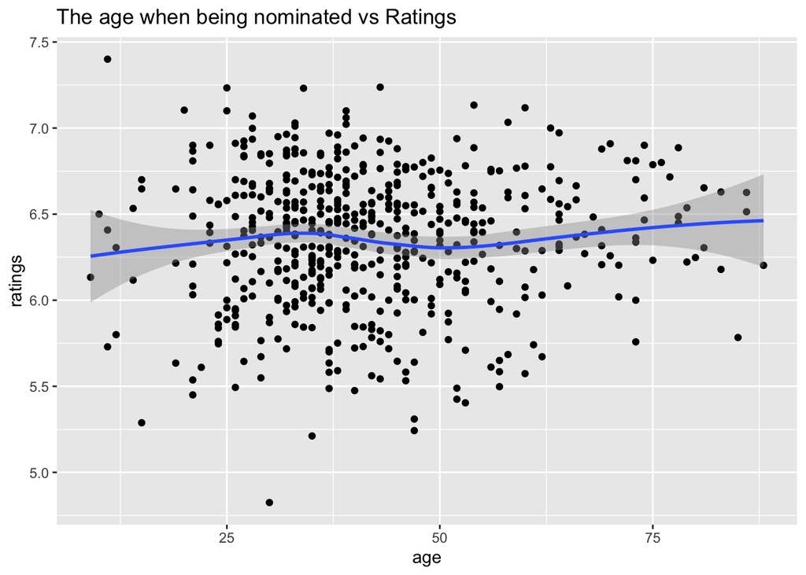

```r
# Combine the nominees dataset with the nominees_rating dataset
reputation %>%
  inner_join(age_first_nominated, by = "name") %>%
  ggplot(aes(x = age, y = ratings)) +
  geom_point()+
  geom_smooth()+
  labs(title = "The age when being nominated vs Ratings")
```

From the plot showing the relationship between the age when nominated and ratings, there’s no clear trend can be summarized. When looking specifically at the age group below 25, ratings are sparsely distributed in the range between 5.25 and 7.50. When looking at the age above 75, ratings are distributed between 7.0 and 5.75, which has smaller variation. Observation of this plot doesn’t support the claim the younger the more talented.

However, there is a possibility that winning an award has a more decisive role in determining an artist’s extraordinarity. Thus, the exploration between the age when artists first win the Oscars Awards and their ratings is needed.

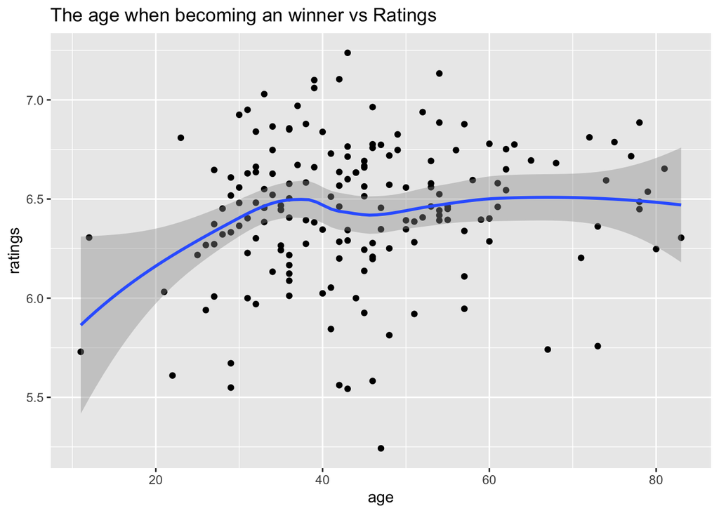

```r
# Combine the winners dataset with the nominees_rating dataset
reputation %>%
  inner_join(age_first_win, by = "name") %>%
  ggplot(aes(x = age, y = ratings)) +
  geom_point()+
  geom_smooth()+
  labs(title = "The age when becoming an winner vs Ratings")
```

The relationship between the age becoming an Oscars winners and the ratings is generally weak, while a positive correlation between the age and ratings can be found in the age group below 40. Nonetheless, this trend contradicts to the intuition of the public, as to prove the public’s hypothesis there should be a negative correlation between the age and the ratings.

Therefore, data in my datasets doesn’t support people’s intuition “the younger the more talented”. Individuals born as performers or other talents might only be rare occasions, while most of the people need exercise and experience to improve their skills. There is also a possibility that individuals reveal their talents at a young age but the talent is just a flash in the pan.

## Conclusion

From 1972 to 2022, there are 556 artists were once nominated as Best Actors, Best Actress, Best Supporting Actors and Best Supporting Actress due to their impressive performances in the film. Among them, 172 artists won Oscars Awards in the intense competition. While most of the artists were only able to be nominated or won the award once, there are artists with multiple statues or becoming Oscars nominees several times. But still, those artists account for a very small portion of the total nominees’ population.

In addition, I also investigate the age distribution of Oscars winners and nominees. The age here refers to the age when they are first nominated or win an award. A scenario can be drawn is that most artists have an achievement from their 30s to 50s, whereas winning an award occurs later in the artist’s career compared to receiving an nomination. Anomalies are Justin Henry and Gloria Stuart who were first nominated at an age of 9 and 88 respectively, and Tatum O’Neal and Christopher Plummer who won the award at an age of 11 and 83 respectively.

The potential relationship between whether or not an actor/actress has Oscars nominations and their reputation of performance is also examined in this EDA. It turns out that nearly 75% of Oscars nominees have ratings above 6.12, indicating that broadly speaking they have better reputation among audiences if to say an average reputation is the rating of 5.00.

One might be curious about the disparity between Oscars voting members’ preference and the general public’s preference. In the section “The Oscars Awards and the rating”, I analyzed the relationship between the number of nominations or wins and the ratings of artists. The result shows that there is certain level of consistency in voting members’ and the general public’s evaluation of artists’ performances—the more the artists receive nominations or win, the higher the ratings. But the Oscars Awards isn’t all, artists with highest ratings might not be the same group of persons with most nominations and wins. Besides, I also use my datasets to examine people’s belief in talented persons will reveal their talents at a very young age. Nevertheless, my datasets doesn’t support this claim. Discovering, exhibiting and maintaining talents will be influenced by various factors when a person grows up and in their career, the age may not be the best perspective to evalueate one’s talent.